# From Text to Meaning

# From text to meaning

### A type-driven Dutch treebank and its applications

#### LSD 2021

#### Kokos

> This presentation and instructions to run it @ github.com/konstantinosKokos/Presentations/LSD2021

# Tiny bit of theory

### The simply typed linear lambda calculus $\lambda^\multimap$

Terms of the form
$$t = var^{\alpha} \ | \ {(t_1^{\alpha \multimap \beta} \ t_2^{\alpha})}^\beta \ | \ {(\lambda x^{\alpha}.t^{\beta})}^{\alpha \multimap \beta}$$

#### Can capture FA-structures in tectosyntax..

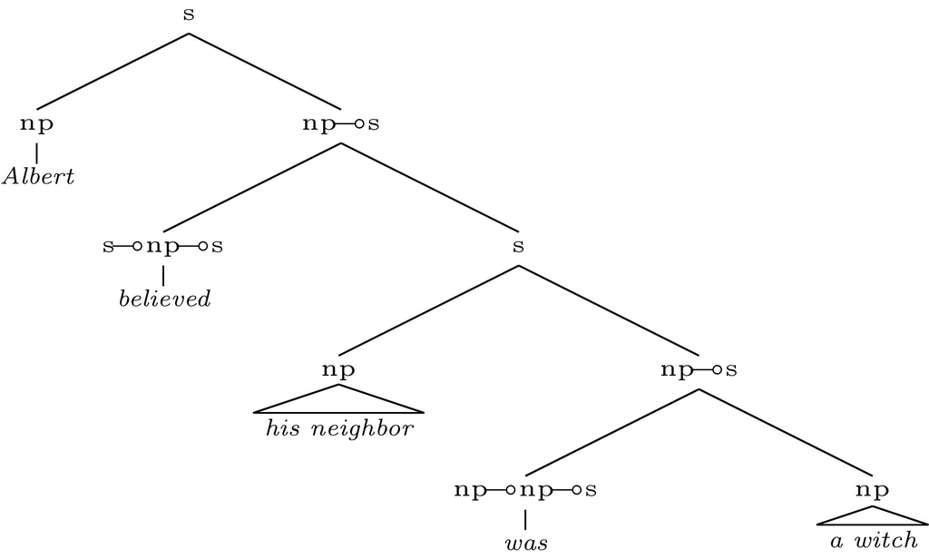

$$\left(
believed^{s\multimap np \multimap s}
\left(
\left(
was^{np \multimap np \multimap s}
\
\left(
{a\ witch}
\right)^{np}
\right)\
\left(
{his\ neighbor}
\right)^{np}
\right)
\right)
\
{Albert}^{np}$$

#### ..inlcuding higher-order phenomena (!)..

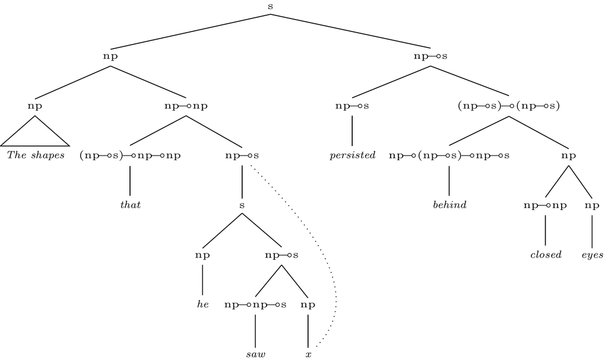

$$\left(
persisted^{np\multimap s}
\left(
behind^{np\multimap (np\multimap s) \multimap np \multimap s}
\left(
closed^{np\multimap np}
eyes^{np}
\right)
\right)
\right)\
\left(
\left(
that^{(np\multimap s)\multimap np\multimap np}
\left(
\lambda x.
\left(
saw^{np\multimap np\multimap s}
x^{np}
\right)\
he^{np}
\right)
\right)
\left(
the^{np\multimap np} shapes^{np}
\right)
\right)$$

#### ..but makes no distinction between signature-sharing words

is, saw :: $np\multimap np \multimap s$

### Adding modalities

$$t = var^{\alpha} \ | \
t_1^{\diamondsuit^\delta \alpha \multimap \beta} \ {\vartriangle^\delta} t_2^{\alpha} \ | \
\blacktriangledown^\delta \!\left(t_1^{\Box^\delta (\alpha \multimap \beta)}\right) \ t_2^{\alpha} \ | \ ...$$

is :: $\diamondsuit^{predc}np \multimap \diamondsuit^{su}np \multimap s$

$$\left(
is \
\vartriangle^{predc}\!\! \left(a\ witch\right)
\right)
\vartriangle^{su}\!\! \left( she \right)$$

saw :: $\diamondsuit^{obj}np \multimap \diamondsuit^{su}np \multimap s$

$$\left(
saw \
\vartriangle^{obj}\!\! (shapes)
\right)
\vartriangle^{su}\!\! \left(he \right)$$

closed :: $\Box^{mod} (np \multimap np)$

$$\blacktriangledown^{mod}(closed) \ eyes$$

```markdown
...
```

# æthel

> *automatically extracted theorems from lassy*

A conversion of Lassy annotations to tecto-grammatic proofs & terms of the above logic.

- access & installation instructions: [github.com/konstantinosKokos/lassy-tlg-extraction](https://github.com/konstantinosKokos/Lassy-TLG-Extraction)
- paper: aclweb.org/anthology/2020.lrec-1.647/

### First step: loading the dataset

```python
import pickle

# remark: change this to your downloaded dataset path
dataset_path = '/home/kokos/Projects/lassy-tlg-extraction/data/train_dev_test_0.4.dev0.p'

with open(dataset_path, 'rb') as f:
    proofs = sum(pickle.load(f), [])
```

#### What does a `proof` look like..?

```python
some_proof = proofs[1312]
print(some_proof)
```

```
ProofNet(proof_frame=Alle:□ᵈᵉᵗ(ɴ → ɴᴘ), films:ɴ, zijn:◊ᵛᶜᴘᴘᴀʀᴛ → ◊ˢᵘɴᴘ → sᴍᴀɪɴ, heel:□ᵐᵒᵈ(ᴀᴘ → ᴀᴘ), barok:ᴀᴘ, versierd:◊ᵖʳᵉᵈᶜᴀᴘ → ᴘᴘᴀʀᴛ ⊢ sᴍᴀɪɴ, axiom_links={(5, 11), (2, 0), (1, 4), (7, 9), (8, 6), (10, 3)}, name='Treebank/WR-P-E-I-0000000332/WR-P-E-I-0000000332.p.4.s.98_0.xml')
```

##### ..a proof frame

A sequence of words & their corresponding *types*, together with a *conclusion* specifying the type of the entire phrase.

```python
print(some_proof.proof_frame)
```

```
Alle:□ᵈᵉᵗ(ɴ → ɴᴘ), films:ɴ, zijn:◊ᵛᶜᴘᴘᴀʀᴛ → ◊ˢᵘɴᴘ → sᴍᴀɪɴ, heel:□ᵐᵒᵈ(ᴀᴘ → ᴀᴘ), barok:ᴀᴘ, versierd:◊ᵖʳᵉᵈᶜᴀᴘ → ᴘᴘᴀʀᴛ ⊢ sᴍᴀɪɴ
```

```python
print(some_proof.proof_frame.get_words())
```

```
['Alle', 'films', 'zijn', 'heel', 'barok', 'versierd']
```

```python
print(some_proof.proof_frame.get_types())
```

```
[□ᵈᵉᵗ(ɴ(-,0) → ɴᴘ(+,1)), ɴ(+,2), ◊ᵛᶜᴘᴘᴀʀᴛ(-,3) → ◊ˢᵘɴᴘ(-,4) → sᴍᴀɪɴ(+,5), □ᵐᵒᵈ(ᴀᴘ(-,6) → ᴀᴘ(+,7)), ᴀᴘ(+,8), ◊ᵖʳᵉᵈᶜᴀᴘ(-,9) → ᴘᴘᴀʀᴛ(+,10)]
```

```python
print(some_proof.proof_frame.conclusion)
```

```
sᴍᴀɪɴ(-,11)
```

##### .. some axiom links

a bijection between *positive* and *negative* atoms (a compressed representation of a proof)

```python
print(some_proof.axiom_links)
```

```
{(5, 11), (2, 0), (1, 4), (7, 9), (8, 6), (10, 3)}
```

##### ..and a name

(optionally) telling us its lassy origins

```python
print(some_proof.name)
```

```
Treebank/WR-P-E-I-0000000332/WR-P-E-I-0000000332.p.4.s.98_0.xml
```

#### Proofs ≡ terms

An intuitionistic logic proof is one and the same to a λ-term (or *program*)

```python
some_proof.print_term(show_words=True)
```

```
'((zijn ▵ᵛᶜ((versierd ▵ᵖʳᵉᵈᶜ((▾ᵐᵒᵈ(heel) barok))))) ▵ˢᵘ((▾ᵈᵉᵗ(Alle) films)))'
```

..modalities (& term decorations) can be dropped to fall back to simple $\lambda^\multimap$ terms

```python
some_proof.print_term(show_words=True, show_decorations=False)
```

```
'((zijn (versierd (heel barok))) (Alle films))'
```

### The Lexicon

From the full collection of proof frames we can aggregate a mapping **Word** $\to$ **{Type}**

```python
from LassyExtraction.aethel import ProofNet
from LassyExtraction.milltypes import WordType

from collections import Counter, defaultdict

def make_lexicon(proofs: list[ProofNet], simple: bool = False) -> dict[str, Counter[WordType]]:
    c = defaultdict(lambda: Counter())
    for pn in proofs:
        for word, wordtype in zip(pn.proof_frame.get_words(), pn.proof_frame.get_types()):
            wordtype = wordtype.depolarize()
            c[word.lower()][wordtype.decolor() if simple else wordtype] += 1
    return c

simple_lexicon = make_lexicon(proofs, True)
deco_lexicon = make_lexicon(proofs, False)
```

```python
simple_lexicon['lezen']
```

```
Counter({ᴡᴡ: 20,
         ɪɴғ: 11,
         ᴠᴢ → ɪɴғ: 3,
         ʙᴡ → ɪɴғ: 1,
         ɴᴘ → ɪɴғ: 6,
         ᴠɴᴡ → ɪɴғ: 1,
         ᴀᴅᴊ → ssᴜʙ: 1,
         ɴᴘ: 3,
         ᴘᴘ → ɪɴғ: 2,
         ᴠᴢ → ɴᴘ → ɪɴғ: 1,
         ᴡʜsᴜʙ → ɪɴғ: 4,
         ᴠᴢ → ʙᴡ → ɴᴘ → ɪɴғ: 1})
```

### Querying the dataset

We can filter sentences satisfying arbitrary predicates

```python
from typing import Callable

def get_proofs(proofs: list[ProofNet], predicate: Callable[[ProofNet], bool]) -> list[ProofNet]:
    return list(filter(predicate, proofs))
```

..like containing a specific word, word-type combination, dependency label, etc.

```python
def containing_word(word: str) -> Callable[[ProofNet], bool]:
    def f(pn: ProofNet) -> bool:
        return word in (w.lower() for w in pn.proof_frame.get_words())
    return f

def containing_dep(dep: str) -> Callable[[ProofNet], bool]:
    def f(pn: ProofNet) -> bool:
        return dep in set.union(*[t.colors() for t in pn.proof_frame.get_types()])
    return f

def containing_word_as(word: str, wordtype: WordType) -> Callable[[ProofNet], bool]:
    def f(pn: ProofNet) -> bool:
        return any(map(lambda w, t: w.lower() == word and t.depolarize() == wordtype,
                      pn.proof_frame.get_words(),
                       pn.proof_frame.get_types()))
    return f
```

```python
from LassyExtraction.milltypes import AtomicType
eenden = get_proofs(proofs, containing_word_as('eenden', AtomicType('N')))
```

### Checking against Lassy

Proofs can be directly compared to the original Lassy annotations

```python
from LassyExtraction.lassy import Lassy, et
from LassyExtraction.viz import ToGraphViz

# remark: change this to point to the LassySmall dir
root_dir = '/home/kokos/Projects/Lassy 4.0/LassySmall'

lassy = Lassy(root_dir = root_dir, ignore='/home/kokos/Projects/lassy-tlg-extraction/LassyExtraction/utils/ignored.txt')
viz = ToGraphViz()


def find_in_lassy(name: str) -> et:
    source, _ = name.split('_')
    return lassy[f'{root_dir}/{source}.xml'][2]
```

```
Ignoring 156 samples..
Dataset constructed with 65045 samples.
```

```python
lassy_tree = find_in_lassy(eenden[0].name)
```

```python
lassy_tree = find_in_lassy('Treebank/dpc-ind-001645-nl-sen/dpc-ind-001645-nl-sen.p.12.s.1_1')
```

```python
viz(lassy_tree)
```

[output not shown]

# Neural Proof Nets

A neural parser based on a *seq2seq* module to translate phrases to proof frames and a *permutation* module to align positive & negative atoms

- access & installation instructions: github.com/konstantinosKokos/neural-proof-nets
- paper: aclweb.org/anthology/2020.conll-1.3/

```python
from Parser.neural.inference import get_model

weights_path = './stored_models/model_weights.model' # remark: change this
device = 'cuda'  # switch

model = get_model(device=device, weights_path=weights_path)
```

```
Initialized.
Loading pre-trained parameters...
Loading model parameters...
Loaded.
```

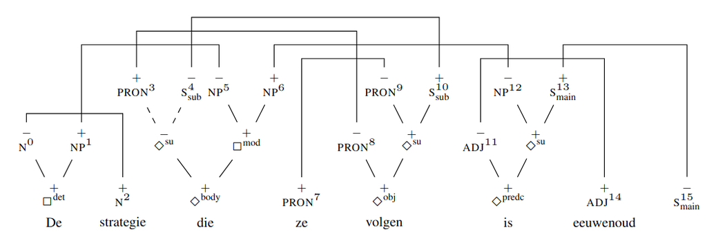

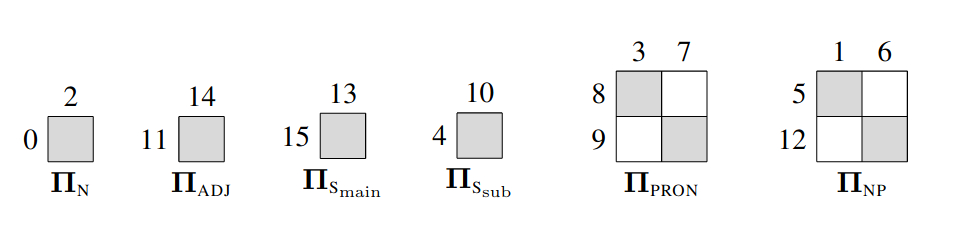

# -- fun but experimental part --

Computing semantics

```python
from LassyExtraction.terms import *
from LassyExtraction.milltypes import *
from functools import partial
from typing import Callable, TypeVar

Meaning = TypeVar('Meaning')

# some standard types
_np, _s = AtomicType('NP'), AtomicType('S')
_itv = FunctorType(_np, _s)
_tv = FunctorType(_np, _itv)
_adj = FunctorType(_np, _np)
# -- corresponding terms
np = lambda x: Lex(_type=_np, idx=x)
itv = lambda x: Lex(_type=_itv, idx=x)
tv = lambda x: Lex(_type=_tv, idx=x)
adj = lambda x: Lex(_type=_adj, idx=x)
# common sentence structures
s1 = Application(itv(1), np(0))
s2 = Application(Application(tv(1), np(2)), np(0))


def meaning(term: Term, word_meanings: dict[int, Meaning]) -> Meaning:
    if isinstance(term, Lex):
        return word_meanings[term.idx]
    if isinstance(term, Application):
        return meaning(term.functor, word_meanings)(meaning(term.argument, word_meanings))
    raise TypeError('only 0-order implicative fragment please!')
```

#### Take 1: model-theoretic semantics

John likes Mary but Mary is a duck!

```python
E = str
T = bool
ET = Callable[[E], T]
EET = Callable[[E], ET]

John:  E = 'John'
Mary:  E = 'Mary'

talks: ET = lambda x: x == John
swims: ET = lambda x: True
flies: ET = lambda x: x == Mary
human: ET = lambda x: talks(x)
duck:  ET = lambda x: swims(x) and flies(x)

is_a:  EET = lambda y: lambda x: y(x)
likes: EET = lambda y: lambda x: True if x == John and y == Mary else False
```